# Identify cell type-specific cell states

Weixu Wang

2022/1/29

In our manuscript, one of the most important tasks is that we how to recover the latent cell states (e.g. four senescence states in Fibroblasts, LowPDctrl (young quiescent cell), HighPDctrl (middle quiescent cell), 50Gy (X-ray induced senescent cells), RS (replicative senescent cell)) for each cell type (e.g. skin fibroblasts in the original Fig. 2D) as we thought it would be a very interesting and biologically meaningful application for ENIGMA. For example, different senescence states of cancer-associated fibroblasts could interact differently with immune cells in the microenvironment of tumor. Puram et al found that the malignant cells in head cancer have three cell states which classify patients into three subtypes (malignant-basal, atypical and classical). We used single cell RNA-seq simulator ESCO (https://github.com/JINJINT/ESCO), combine with real single cell datasets, to generate a simulated datasets to illustrate the superior performance of ENIGMA.

## 1. Latent cell type-specific trajectory identification

In the first section, I would use simulated bulk mixture with the Cell Type 1 has trajectory structure and Cell Type 3 has cell cluster structure to illustrate how ENIGMA could identify the latent cell states of the cell types in bulk samples. The datasets could be downloaded from https://github.com/WWXkenmo/ENIGMA_analysis/tree/main/ENIGMA_analysis/Data/CellStateIdentification/Traj

### Load Datasets

```r
suppressPackageStartupMessages(library(ggplot2))
suppressPackageStartupMessages(library(SingleCellExperiment))
suppressPackageStartupMessages(library(scater))
suppressPackageStartupMessages(library(ENIGMA))
suppressPackageStartupMessages(library(destiny))
#load the datasets
Bulk = readRDS("PseudoBulk.rds")
idCell = readRDS("idCell.rds")
ref = readRDS("ref.rds")
groundtruth = readRDS("groundtruth.rds")
```

The idCell object contains the cell type-specific cell states information of each sample.

```r
head(idCell)
```

```
##          Cell.Trajectory CellType2 CellType3
## Sample-1             818      <NA>    Group2
## Sample-2             208      <NA>    Group1
## Sample-3             783      <NA>    Group2
## Sample-4             423      <NA>    Group2
## Sample-5             398      <NA>    Group1
## Sample-6             293      <NA>    Group2
```

```r
cse <- SingleCellExperiment(assays=list(logcounts = groundtruth[1,,]))
cse$Step <- as.numeric(as.matrix(idCell$Cell.Trajectory))
dc <- DiffusionMap(cse,n_local = 50, n_pcs = 5,verbose = TRUE)
```

```
## finding knns......done. Time: 0.06s
## Calculating transition probabilities......done. Time: 0.01s
##
## performing eigen decomposition......done. Time: 0.01s
```

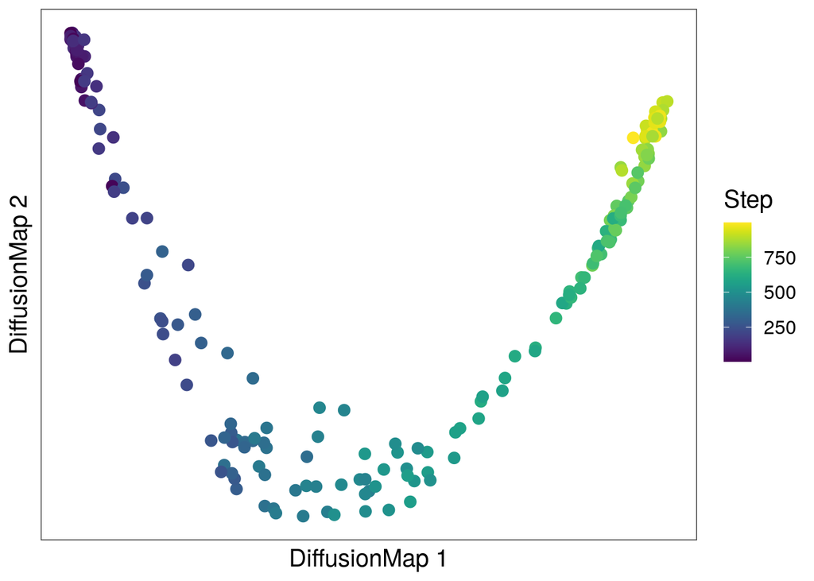

```r
DC_embedding <- cbind(dc$DC1,dc$DC2)
colnames(DC_embedding) <- c("DC1","DC2")
reducedDim(cse, "DiffusionMap") <- DC_embedding

plotReducedDim(cse,colour_by = "Step",dimred = "DiffusionMap",point_size = 3,point_alpha=1)+theme_bw()+theme(axis.text = element_blank(),axis.ticks = element_blank(),panel.grid = element_blank(),text = element_text(size=15))
```

And also, the cell type3 latently have cell type specific clusters structure.

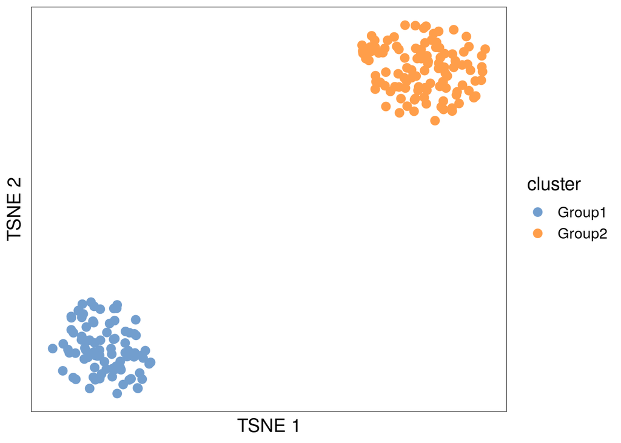

```r
cse <- SingleCellExperiment(assays=list(logcounts = groundtruth[3,,]))
cse$cluster <- idCell$CellType3
cse <- runTSNE(cse)

plotReducedDim(cse,colour_by = "cluster",dimred = "TSNE",point_size = 3,point_alpha=1)+theme_bw()+theme(axis.text = element_blank(),axis.ticks = element_blank(),panel.grid = element_blank(),text = element_text(size=15))
```

However, if we use bulk mixture, we would not see the trajectory structure but only the cluster structure of cell type 3.

```r
cse <- SingleCellExperiment(assays=list(logcounts = Bulk))
cse$step <- as.numeric(as.matrix(idCell$Cell.Trajectory))
cse$cluster <- idCell$CellType3
cse <- runTSNE(cse)

dc <- DiffusionMap(cse,n_local = 50, n_pcs = 5,verbose = TRUE)
```

```
## finding knns......done. Time: 0.04s
## Calculating transition probabilities......done. Time: 0.00s
##
## performing eigen decomposition......done. Time: 0.00s
```

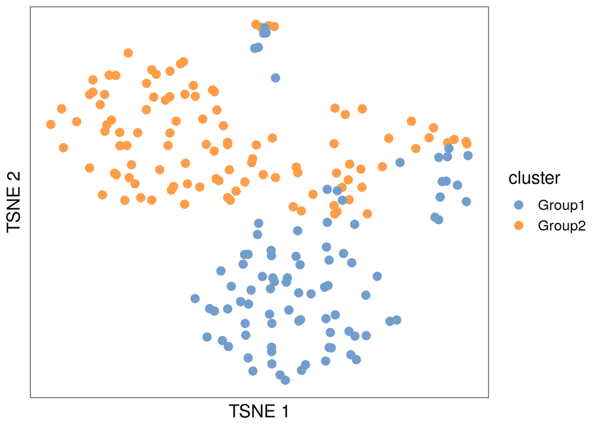

```r
DC_embedding <- cbind(dc$DC1,dc$DC2)
colnames(DC_embedding) <- c("DC1","DC2")
reducedDim(cse, "DiffusionMap") <- DC_embedding

plotReducedDim(cse,colour_by = "cluster",dimred = "TSNE",point_size = 3,point_alpha=1)+theme_bw()+theme(axis.text = element_blank(),axis.ticks = element_blank(),panel.grid = element_blank(),text = element_text(size=15))
```

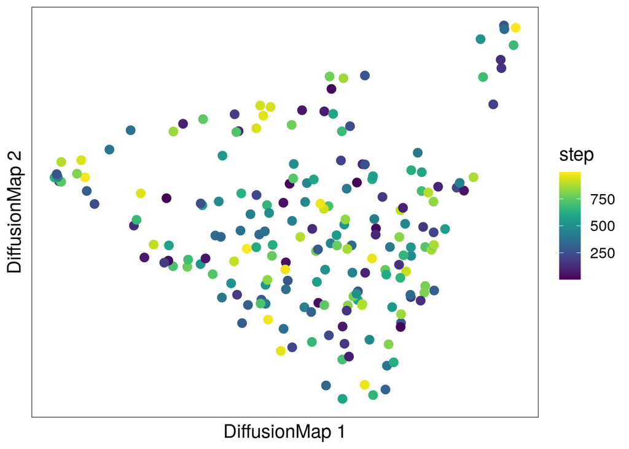

```r
plotReducedDim(cse,colour_by = "step",dimred = "DiffusionMap",point_size = 3,point_alpha=1)+theme_bw()+theme(axis.text = element_blank(),axis.ticks = element_blank(),panel.grid = element_blank(),text = element_text(size=15))
```

To reveal the latent cell type specific variation of cell type 1, we need to perform deconvolution.

### Perform deconvolution

We used ENIGMA to perform deconvolution, and user could use follow command to perform analysis

```r
egm = create_ENIGMA(bulk = Bulk, ref_type = "aggre", ref = ref)
```

```
## Sat Jan 29 20:30:10 2022 Reference from aggregated FACS/Sort Bulk RNA-seq/microarray/scRNA-seq.
```

```r
## our reference is the average expression of ground truth profile.

## deconvolution
egm = get_cell_proportion(egm,method = "RLR")
```

```
## Sat Jan 29 20:30:10 2022 Calculating cell type proportion of bulk samples...
## Using Robust Linear Regression...
```

```r
egm = ENIGMA_L2_max_norm(egm,Norm.method = "PC",alpha = 0.1,beta = 0.5)
```

```
## Sat Jan 29 20:30:16 2022 Optimizing cell type specific expression profile...
## Converge in 9 steps
```

```r
### alpha = 0.1 because our reference is very close to ground truth profile, in supplementary note, we have discuss the effects of parameter alpha on numerical output.

## convert output of ENIGMA into array format
CSE = sce2array(egm)
```

Then, we could visualize the inferred cell type 1 expression profile of ENIGMA

```r
cse <- SingleCellExperiment(assays=list(logcounts = CSE[,,1]))
cse$Step <- as.numeric(as.matrix(idCell$Cell.Trajectory))
cse <- cse[,egm@result_cell_proportion[,1]>0.05] # filter the sample with low cell type fractions of cell type 1
dc <- DiffusionMap(cse,n_local = 50, n_pcs = 5,verbose = TRUE)
```

```
## finding knns......done. Time: 0.04s
## Calculating transition probabilities......done. Time: 0.00s
##
## performing eigen decomposition......done. Time: 0.00s
```

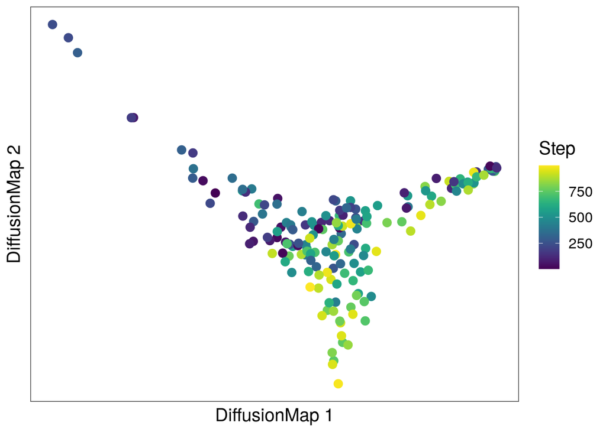

```r
DC_embedding <- cbind(dc$DC1,dc$DC2)
colnames(DC_embedding) <- c("DC1","DC2")
reducedDim(cse, "DiffusionMap") <- DC_embedding
cse <- runPCA(cse)

plotReducedDim(cse,colour_by = "Step",dimred = "DiffusionMap",point_size = 3,point_alpha=1)+theme_bw()+theme(axis.text = element_blank(),axis.ticks = element_blank(),panel.grid = element_blank(),text = element_text(size=15))
```

## 2. Identify four senescent associate cell states in fibroblast cells

In the second section, I simulated the bulk mixture based on real scRNA-seq datasets. A fibroblast single cell RNA-seq datasets with four senescenet cell states. We also simulated cell type 2 and cell type3, in which cell type 3 also have two clusters (cell stats).

We also loaded the datasets and visualize the bulk with its cell type 1 state label and cell type 3 state label, the datasets could be downloaded from https://github.com/WWXkenmo/ENIGMA_analysis/tree/main/ENIGMA_analysis/Data/CellStateIdentification/Senescence

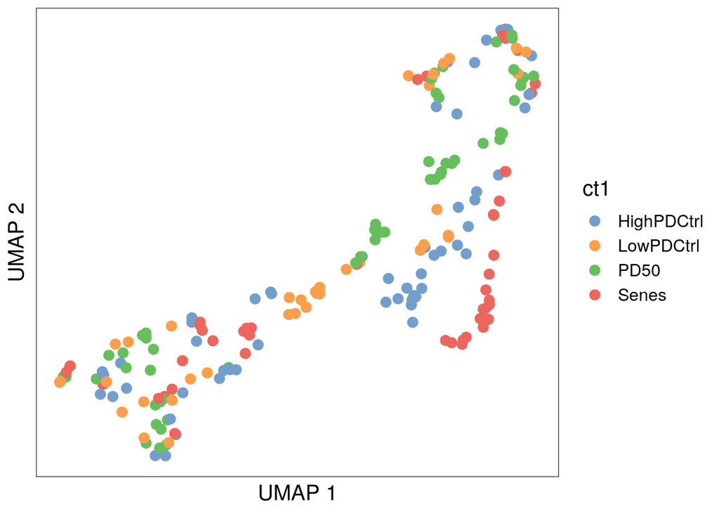

```r
#load the datasets
Bulk = readRDS("/mnt/data1/weixu/HiDe/revised/Senescence/PseudoBulk.rds")
idCell = readRDS("/mnt/data1/weixu/HiDe/revised/Senescence/idCell.rds")
ref = readRDS("/mnt/data1/weixu/HiDe/revised/Senescence/ref.rds")

cse <- SingleCellExperiment(assays=list(logcounts = Bulk))
cse$ct1 <- idCell$Fibroblast
cse$ct3 <- idCell$CellType3
cse <- runPCA(cse)
cse <- runUMAP(cse,dimred="PCA",n_dimred=10)

plotReducedDim(cse,colour_by = "ct1",dimred = "UMAP",point_size = 3,point_alpha=1)+theme_bw()+theme(axis.text = element_blank(),axis.ticks = element_blank(),panel.grid = element_blank(),text = element_text(size=15))
```

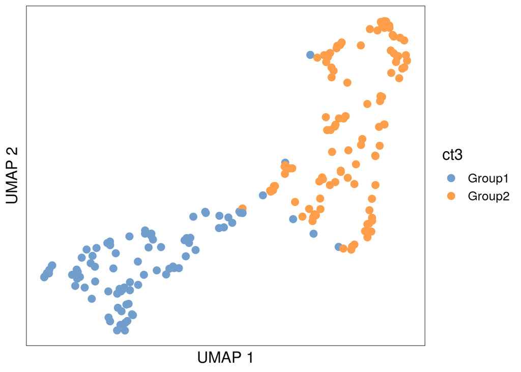

```r
plotReducedDim(cse,colour_by = "ct3",dimred = "UMAP",point_size = 3,point_alpha=1)+theme_bw()+theme(axis.text = element_blank(),axis.ticks = element_blank(),panel.grid = element_blank(),text = element_text(size=15))
```

As we can see, the bulk expression profile is largly biased by the variation of cell type 3 but not cell type 1.

We used ENIGMA to perform deconvolution, and user could use follow command to perform analysis

```r
egm = create_ENIGMA(bulk = Bulk, ref_type = "aggre", ref = ref)
```

```
## Sat Jan 29 20:30:49 2022 Reference from aggregated FACS/Sort Bulk RNA-seq/microarray/scRNA-seq.
```

```r
## our reference is the average expression of ground truth profile.

## deconvolution
egm = get_cell_proportion(egm,method = "RLR")
```

```
## Sat Jan 29 20:30:49 2022 Calculating cell type proportion of bulk samples...
## Using Robust Linear Regression...
```

```r
egm = ENIGMA::ENIGMA_L2_max_norm(egm,Norm.method = "PC",alpha = 0.1,beta = 0.5)
```

```
## Sat Jan 29 20:30:54 2022 Optimizing cell type specific expression profile...
## Converge in 9 steps
```

```r
### alpha = 0.1 because our reference is very close to ground truth profile, in supplementary note, we have discuss the effects of parameter alpha on numerical output.

## convert output of ENIGMA into array format
CSE = sce2array(egm)
```

Then, we could visualize the inferred cell type 1 expression profile of ENIGMA

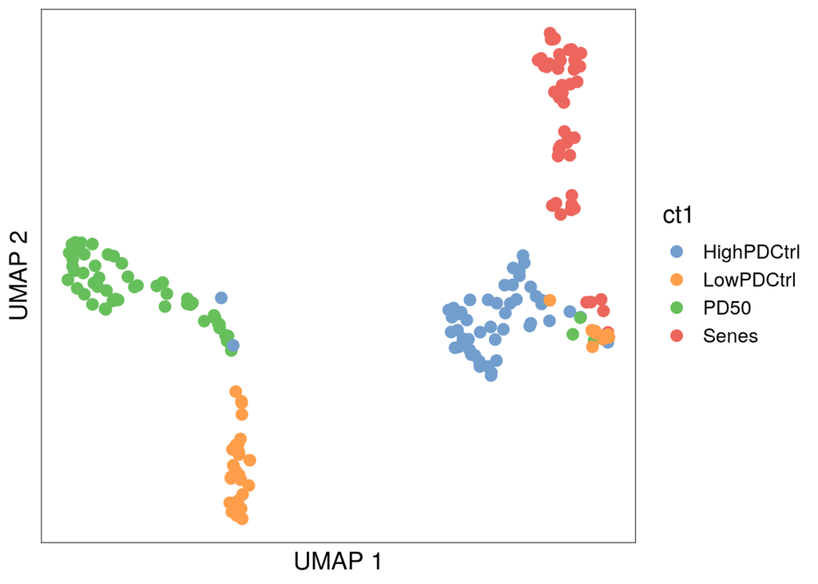

```r
cse <- SingleCellExperiment(assays=list(logcounts = CSE[,,1]))
cse$ct1 <- idCell$Fibroblast
cse$ct3 <- idCell$CellType3
cse <- cse[,egm@result_cell_proportion[,1]>0.05] # filter the sample with low cell type fractions of cell type 1
cse <- runPCA(cse)
cse <- runUMAP(cse,dimred="PCA",n_dimred=10)

plotReducedDim(cse,colour_by = "ct1",dimred = "UMAP",point_size = 3,point_alpha=1)+theme_bw()+theme(axis.text = element_blank(),axis.ticks = element_blank(),panel.grid = element_blank(),text = element_text(size=15))
```

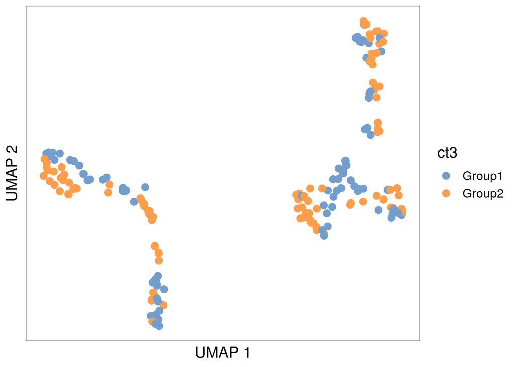

```r
plotReducedDim(cse,colour_by = "ct3",dimred = "UMAP",point_size = 3,point_alpha=1)+theme_bw()+theme(axis.text = element_blank(),axis.ticks = element_blank(),panel.grid = element_blank(),text = element_text(size=15))
```

We could found that inferred CSE of cell type 1 only preserve the cluster structure of senescence states but not the cluster structure of cell type 3. And suppose we look at the profile of cell type 3

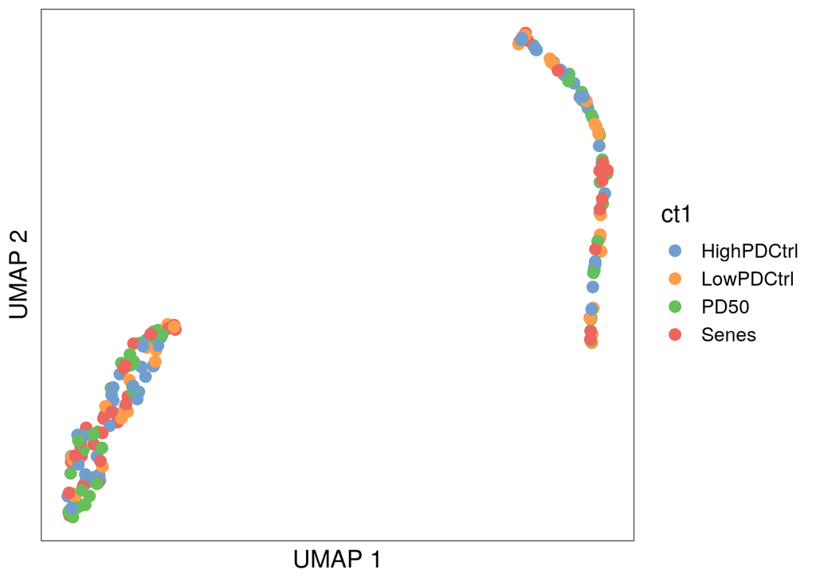

```r
cse <- SingleCellExperiment(assays=list(logcounts = CSE[,,3]))
cse$ct1 <- idCell$Fibroblast
cse$ct3 <- idCell$CellType3
cse <- cse[,egm@result_cell_proportion[,3]>0.05] # filter the sample with low cell type fractions of cell type 1
cse <- runPCA(cse)
cse <- runUMAP(cse,dimred="PCA",n_dimred=10)

plotReducedDim(cse,colour_by = "ct1",dimred = "UMAP",point_size = 3,point_alpha=1)+theme_bw()+theme(axis.text = element_blank(),axis.ticks = element_blank(),panel.grid = element_blank(),text = element_text(size=15))
```

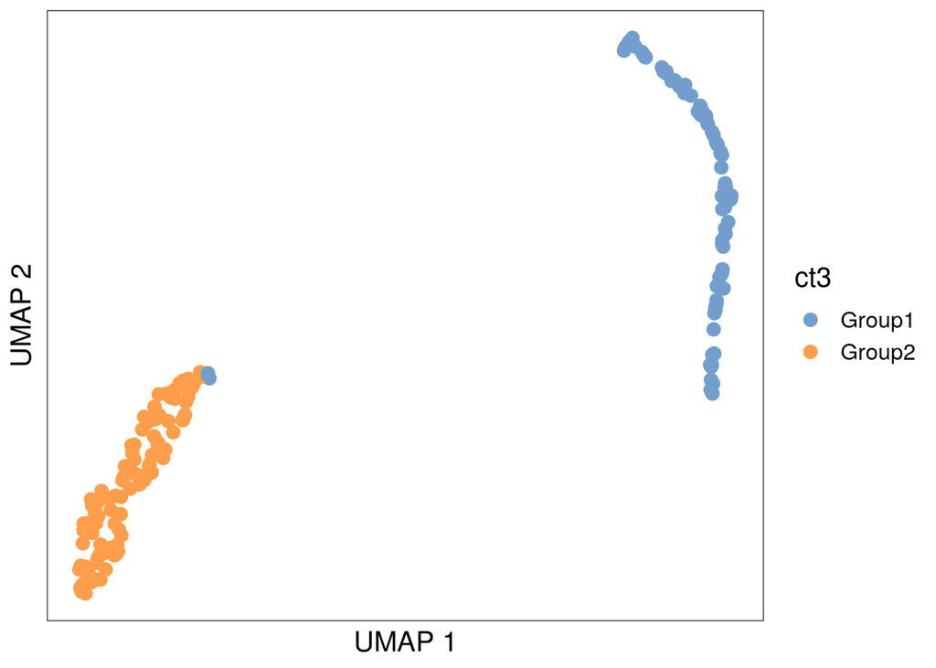

```r
plotReducedDim(cse,colour_by = "ct3",dimred = "UMAP",point_size = 3,point_alpha=1)+theme_bw()+theme(axis.text = element_blank(),axis.ticks = element_blank(),panel.grid = element_blank(),text = element_text(size=15))
```

We found inferred cell type 3 only preserve the binary cluster structure.